# Njoroge et al 2021 Meta-analysis MS script

#### 2.6.7.2 Conduct model selection using glmulti

```r
library(rJava)
library(glmulti)
library(metafor)
```

Define a function that takes a model formula and a dataset as input and then fits a random or mixed-effects meta-regression model to the given data using maximum likelihood estimation:

```r
rma.glmulti <- function(formula, data, ...)
  rma(formula, vi, data=data, method="ML", ...)
```

Here we ensure that we only keep rows with no missing data from all predictors used. we used the metaregression results to choose the moderators to use in glmulti. Moderators that were not significant were dropped apart from precipitation_levels since its part of our 2nd hypothesis.

```r
dim(litmeta)
litmeta2 <- litmeta[!apply(litmeta[,c( "Lit_Car", "Time_Days", "sp_div_in_mixture", "Fauna_available","climatic_region","Annual_precip", "Lit_Pho" )], 1, anyNA),]
dim(litmeta2)
```

```
## [1] 867  56
## [1] 466  56
```

```r
res <- glmulti(yi ~Lit_Car + Lit_Pho + Time_Days+ sp_div_in_mixture+ Fauna_available:precipitation_levels+
                 Fauna_available+climatic_region+precipitation_levels, data=litmeta2,
               level=1, fitfunction=rma.glmulti, crit="aicc")
```

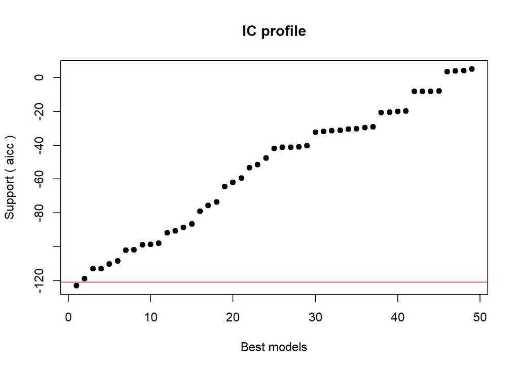

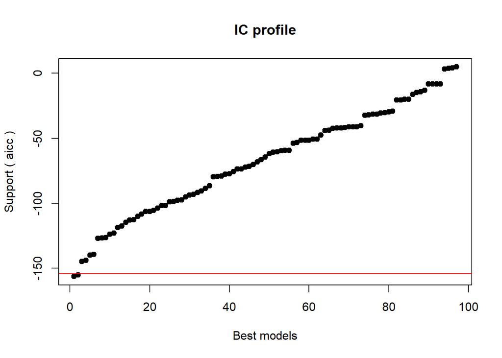

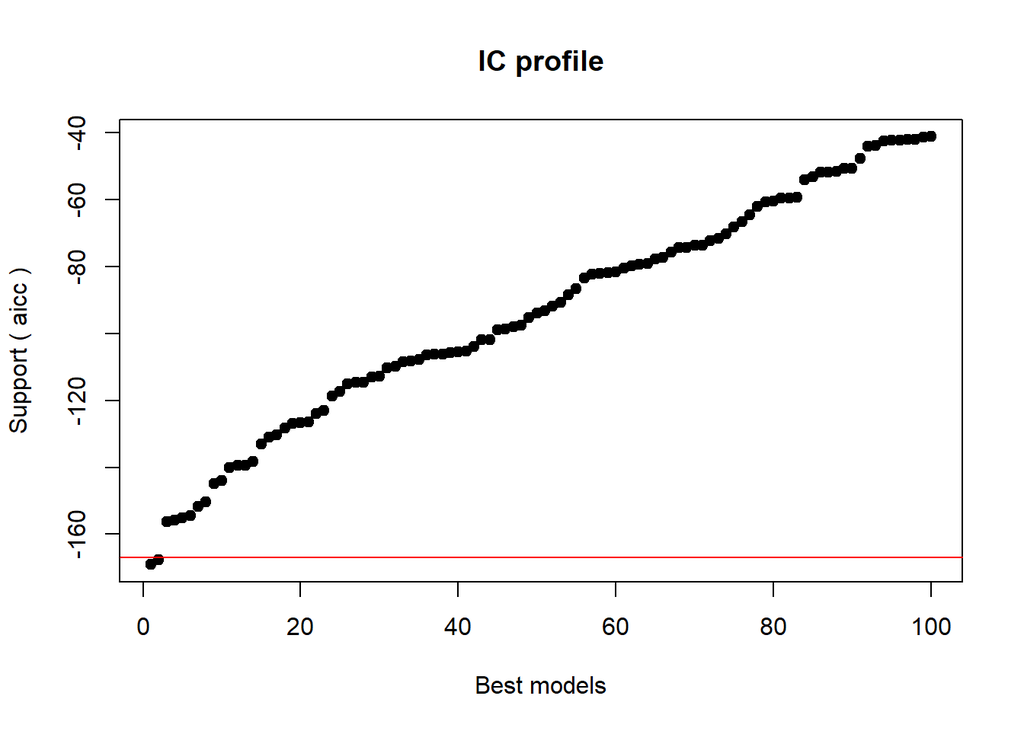

```
## Initialization...
## TASK: Exhaustive screening of candidate set.
## Fitting...
##
## After 50 models:
## Best model: yi~1+Fauna_available+Lit_Car+Lit_Pho+Time_Days+sp_div_in_mixture
## Crit= -122.953637663603
## Mean crit= -54.2749342612702
##
## After 100 models:
## Best model: yi~1+Fauna_available+precipitation_levels+Lit_Car+Lit_Pho+Time_Days
## Crit= -156.353640292807
## Mean crit= -67.8887311541515
##
## After 150 models:
## Best model: yi~1+Fauna_available+climatic_region+precipitation_levels+Lit_Car+Lit_Pho+Time_Days
## Crit= -169.07409277618
## Mean crit= -94.0440951685833
## Completed.
```

##### 2.6.7.2.1 Brief summary of the results

```r
print (res)
```

```
## glmulti.analysis
## Method: h / Fitting: rma.glmulti / IC used: aicc
## Level: 1 / Marginality: FALSE
## From 100 models:
## Best IC: -169.07409277618
## Best model:
## [1] "yi ~ 1 + Fauna_available + climatic_region + precipitation_levels + "
## [2] "    Lit_Car + Lit_Pho + Time_Days"
## Evidence weight: 0.67802489142905
## Worst IC: -41.142934082675
## 2 models within 2 IC units.
## 1 models to reach 95% of evidence weight.
```

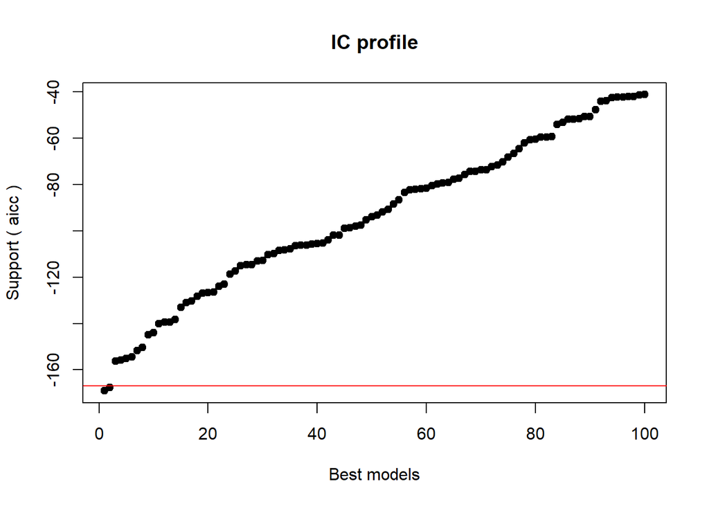

```r
plot(res)
```

```r
top <- weightable(res)
top <- top[top$aicc <= min(top$aicc) + 2,]
top
```

```
##                                                                                                                   model
## 1                     yi ~ 1 + Fauna_available + climatic_region + precipitation_levels + Lit_Car + Lit_Pho + Time_Days
## 2 yi ~ 1 + Fauna_available + climatic_region + precipitation_levels + Lit_Car + Lit_Pho + Time_Days + sp_div_in_mixture
##        aicc   weights
## 1 -169.0741 0.6780249
## 2 -167.5639 0.3186496
```

##### 2.6.7.2.4 Examine the best model

```r
summary(res@objects[[1]])
```

```
##
## Mixed-Effects Model (k = 466; tau^2 estimator: ML)
##
##    logLik   deviance        AIC        BIC       AICc
##   94.7788  1244.6535  -169.5576  -128.1158  -169.0741
##
## tau^2 (estimated amount of residual heterogeneity):     0.0134 (SE = 0.0014)
## tau (square root of estimated tau^2 value):             0.1156
## I^2 (residual heterogeneity / unaccounted variability): 100.00%
## H^2 (unaccounted variability / sampling variability):   36850.95
## R^2 (amount of heterogeneity accounted for):            52.12%
##
## Test for Residual Heterogeneity:
## QE(df = 457) = 13986255.4151, p-val < .0001
##
## Test of Moderators (coefficients 2:9):
## QM(df = 8) = 276.4170, p-val < .0001
##
## Model Results:
##
##                             estimate      se     zval    pval    ci.lb    ci.ub
## intrcpt                       0.7805  0.0895   8.7218  <.0001   0.6051   0.9558
## Fauna_availablepresent        0.0914  0.0205   4.4546  <.0001   0.0512   0.1317
## climatic_regionTemperate     -0.0718  0.0243  -2.9596  0.0031  -0.1193  -0.0242
## climatic_regionTropics       -0.1395  0.0352  -3.9644  <.0001  -0.2084  -0.0705
## precipitation_levelslow      -0.2272  0.0402  -5.6473  <.0001  -0.3061  -0.1484
## precipitation_levelsmedium   -0.2420  0.0333  -7.2670  <.0001  -0.3073  -0.1767
## Lit_Car                      -0.0129  0.0020  -6.3824  <.0001  -0.0169  -0.0090
## Lit_Pho                      -0.1130  0.0285  -3.9600  <.0001  -0.1689  -0.0571
## Time_Days                     0.0002  0.0000   7.8360  <.0001   0.0002   0.0003
##
## intrcpt                     ***
## Fauna_availablepresent      ***
## climatic_regionTemperate     **
## climatic_regionTropics      ***
## precipitation_levelslow     ***
## precipitation_levelsmedium  ***
## Lit_Car                     ***
## Lit_Pho                     ***
## Time_Days                   ***
##
## ---
## Signif. codes:  0 '***' 0.001 '**' 0.01 '*' 0.05 '.' 0.1 ' ' 1
```

### 2.6.8 Remaing figures

Combine the plots into different panels for the manuscript using patchwork

[figure not shown]

```r
library(patchwork)
fig5<- plot3 + plot11 + plot12
fig5
```

```r
ggsave(filename="figure5.png", plot=fig5, device="png",
       path=path, height=5, width=15, units="in", dpi=500)
```

#### 2.6.8.2 Fig 4

[figure not shown]

```r
library(patchwork)
fig4<- plot6 + plot9 + plot10
fig4
```

```r
ggsave(filename="figure4.png", plot=fig4, device="png",
       path=path, height=5, width=15, units="in", dpi=500)
```

# 3 Conclusion